# Evaluación módulo 5

## Modelos finales, resultados y comparativa

Se presentan a continuación los modelos finales y sus resultados:

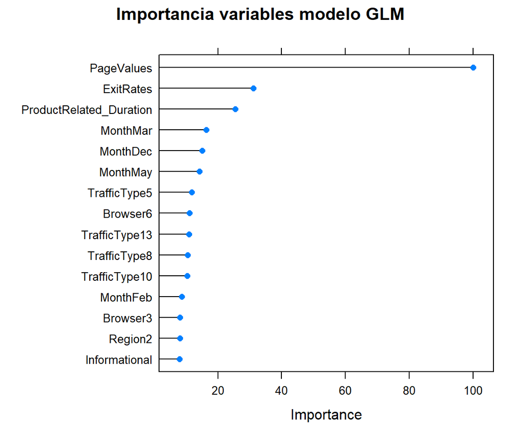

```r
set.seed(7)
#GLM
plot(varImp(glm),top=15, main="Importancia variables modelo GLM")
```

```r
#Perceptron Multicapa
roc_mlp<-Resul_Modelo(mlp)
```

```
## [1] "Mejor modelo:"
##   size
## 1    1
## [1] "ROC del modelo con el fichero de validación: 0.908543946499913"
```

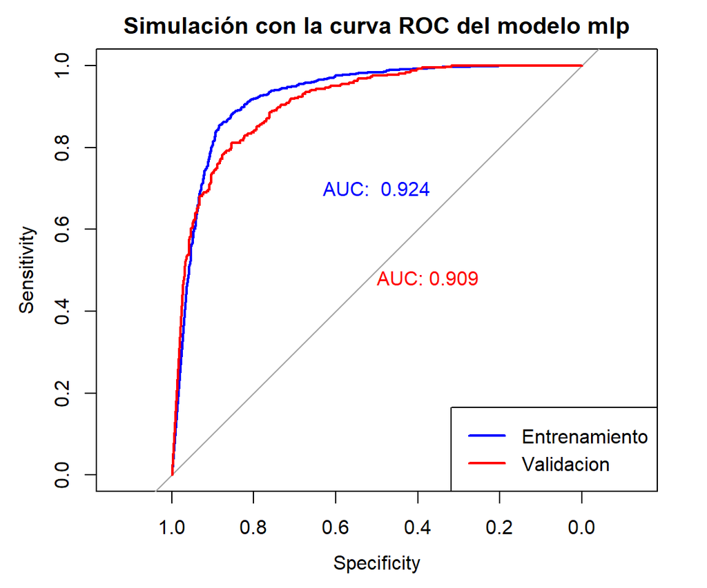

```
## Cross-Validated (5 fold, repeated 3 times) Confusion Matrix
##
## (entries are percentual average cell counts across resamples)
##
##           Reference
## Prediction    n    y
##          n 50.6  6.7
##          y  7.9 34.8
##
##  Accuracy (average) : 0.8541
##
##
##
##    Cell Contents
## |-------------------------|
## |                       N |
## | Chi-square contribution |
## |           N / Row Total |
## |           N / Col Total |
## |         N / Table Total |
## |-------------------------|
##
##
## Total Observations in Table:  974
##
##
##              | validacion$Revenue
##       pred_Y |         n |         y | Row Total |
## -------------|-----------|-----------|-----------|
##            n |       487 |        78 |       565 |
##              |    73.935 |   104.314 |           |
##              |     0.862 |     0.138 |     0.580 |
##              |     0.854 |     0.193 |           |
##              |     0.500 |     0.080 |           |
## -------------|-----------|-----------|-----------|
##            y |        83 |       326 |       409 |
##              |   102.135 |   144.101 |           |
##              |     0.203 |     0.797 |     0.420 |
##              |     0.146 |     0.807 |           |
##              |     0.085 |     0.335 |           |
```

[output cut: 14 more lines]

```
## x           n         y
##   n 0.8619469 0.1380531
##   y 0.2029340 0.7970660
##
## $prop.col
##    y
## x           n         y
##   n 0.8543860 0.1930693
##   y 0.1456140 0.8069307
##
## $prop.tbl
##    y
## x            n          y
##   n 0.50000000 0.08008214
##   y 0.08521561 0.33470226
```

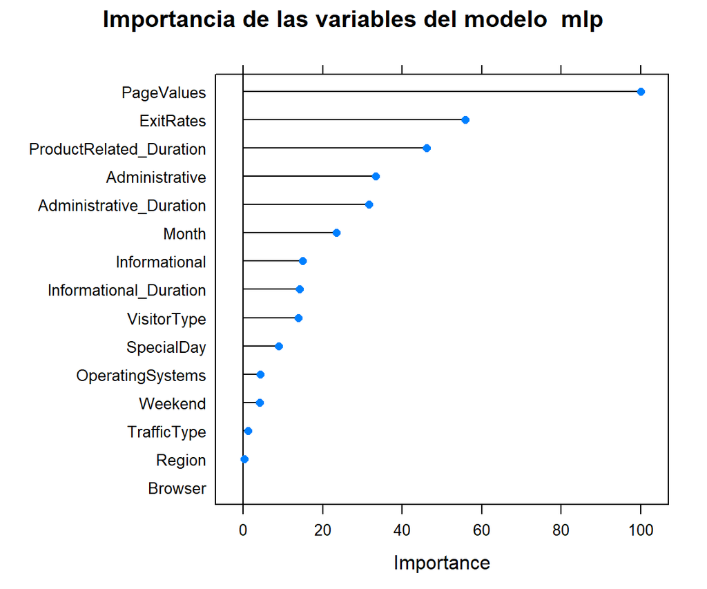

```r
#Máquina vector de soporte
roc_svm<-Resul_Modelo(svm)
```

```
## [1] "Mejor modelo:"
##     sigma C
## 50 0.0125 1
## [1] "ROC del modelo con el fichero de validación: 0.905819002952927"
```

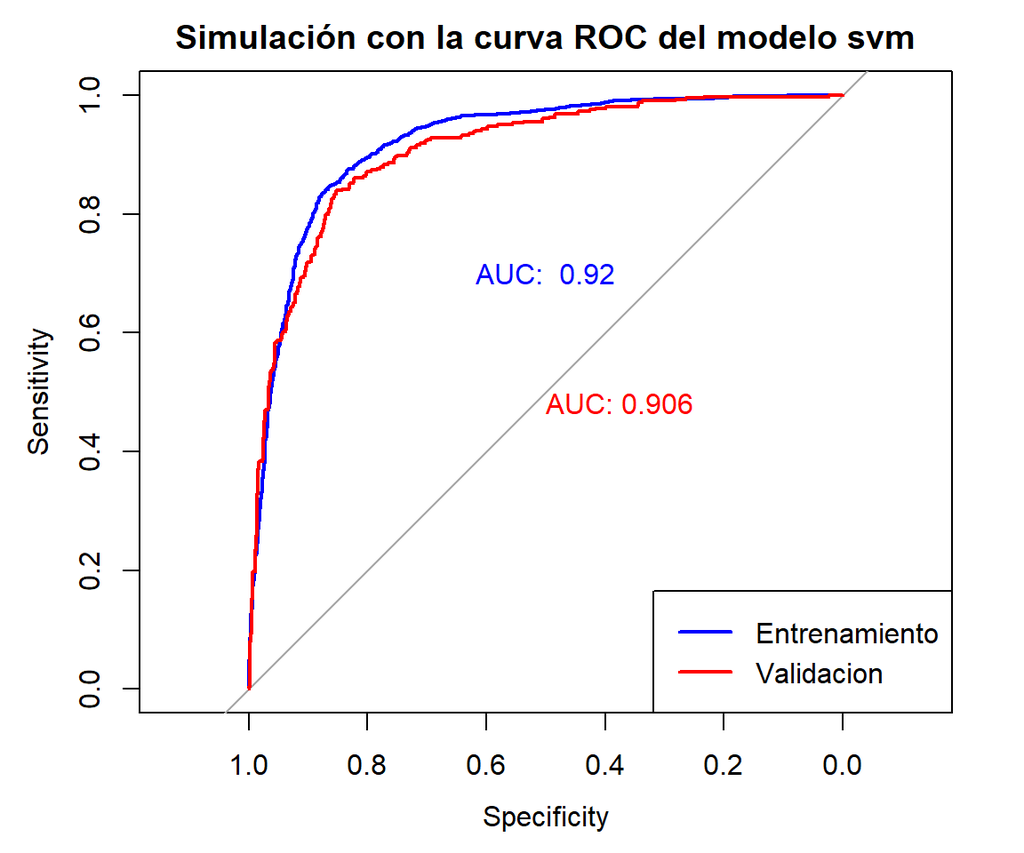

```
## Cross-Validated (5 fold, repeated 3 times) Confusion Matrix
##
## (entries are percentual average cell counts across resamples)
##
##           Reference
## Prediction    n    y
##          n 53.8 12.5
##          y  4.7 29.0
##
##  Accuracy (average) : 0.8277
##
##
##
##    Cell Contents
## |-------------------------|
## |                       N |
## | Chi-square contribution |
## |           N / Row Total |
## |           N / Col Total |
## |         N / Table Total |
## |-------------------------|
##
##
## Total Observations in Table:  974
##
##
##              | validacion$Revenue
##       pred_Y |         n |         y | Row Total |
## -------------|-----------|-----------|-----------|
##            n |       523 |       130 |       653 |
##              |    51.917 |    73.249 |           |
##              |     0.801 |     0.199 |     0.670 |
##              |     0.918 |     0.322 |           |
##              |     0.537 |     0.133 |           |
## -------------|-----------|-----------|-----------|
##            y |        47 |       274 |       321 |
##              |   105.613 |   149.009 |           |
##              |     0.146 |     0.854 |     0.330 |
##              |     0.082 |     0.678 |           |
##              |     0.048 |     0.281 |           |
```

[output cut: 14 more lines]

```
## x           n         y
##   n 0.8009188 0.1990812
##   y 0.1464174 0.8535826
##
## $prop.col
##    y
## x            n          y
##   n 0.91754386 0.32178218
##   y 0.08245614 0.67821782
##
## $prop.tbl
##    y
## x            n          y
##   n 0.53696099 0.13347023
##   y 0.04825462 0.28131417
```

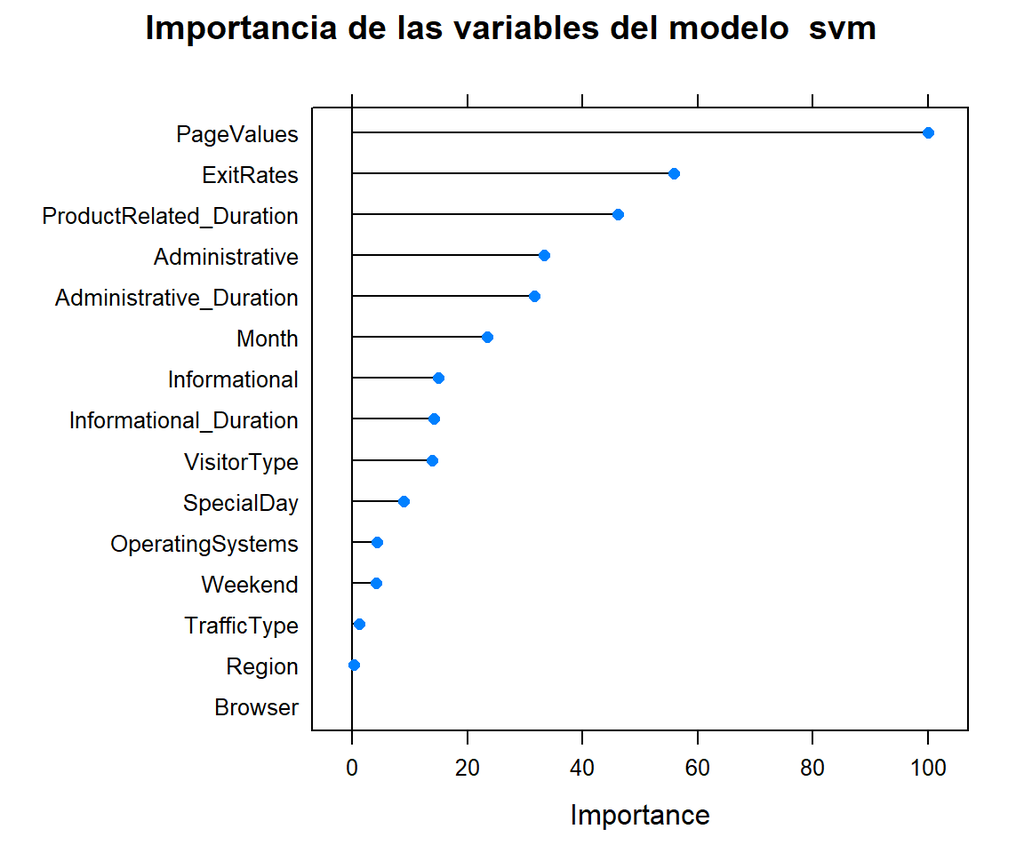

```r
#K vecinos
roc_knn<-Resul_Modelo(knn2)
```

```
## [1] "Mejor modelo:"
##     k
## 14 43
## [1] "ROC del modelo con el fichero de validación: 0.853426263678999"
```

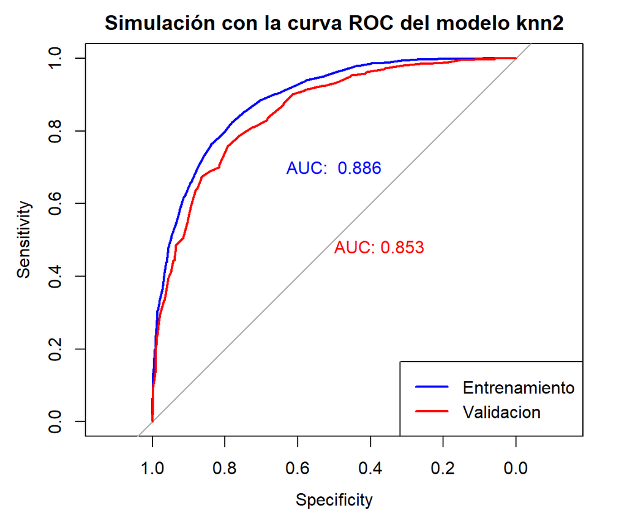

```
## Cross-Validated (5 fold, repeated 3 times) Confusion Matrix
##
## (entries are percentual average cell counts across resamples)
##
##           Reference
## Prediction    n    y
##          n 52.0 15.4
##          y  6.5 26.1
##
##  Accuracy (average) : 0.7809
##
##
##
##    Cell Contents
## |-------------------------|
## |                       N |
## | Chi-square contribution |
## |           N / Row Total |
## |           N / Col Total |
## |         N / Table Total |
## |-------------------------|
##
##
## Total Observations in Table:  974
##
##
##              | validacion$Revenue
##       pred_Y |         n |         y | Row Total |
## -------------|-----------|-----------|-----------|
##            n |       501 |       145 |       646 |
##              |    39.987 |    56.417 |           |
##              |     0.776 |     0.224 |     0.663 |
##              |     0.879 |     0.359 |           |
##              |     0.514 |     0.149 |           |
## -------------|-----------|-----------|-----------|
##            y |        69 |       259 |       328 |
##              |    78.754 |   111.113 |           |
##              |     0.210 |     0.790 |     0.337 |
##              |     0.121 |     0.641 |           |
##              |     0.071 |     0.266 |           |
```

[output cut: 14 more lines]

```
## x           n         y
##   n 0.7755418 0.2244582
##   y 0.2103659 0.7896341
##
## $prop.col
##    y
## x           n         y
##   n 0.8789474 0.3589109
##   y 0.1210526 0.6410891
##
## $prop.tbl
##    y
## x            n          y
##   n 0.51437372 0.14887064
##   y 0.07084189 0.26591376
```

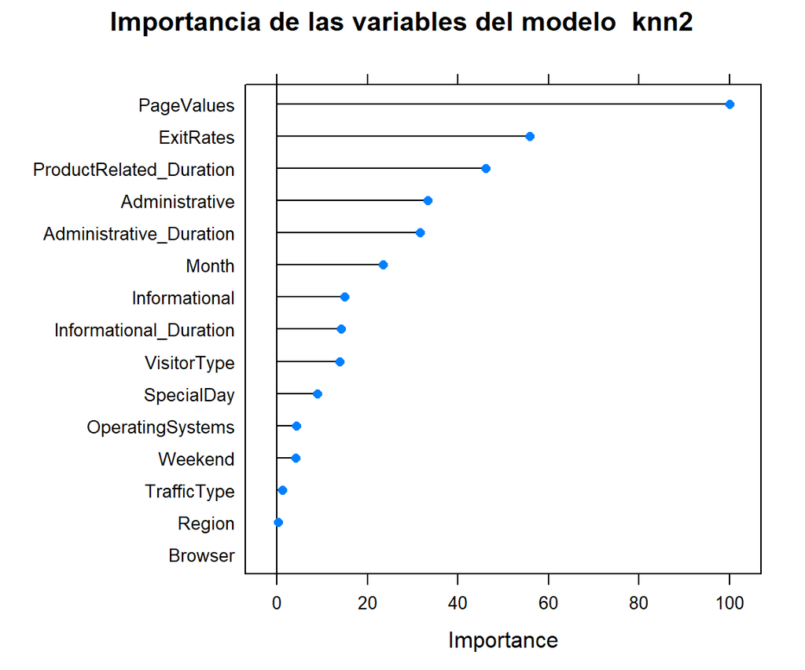

```r
#Adaboost
roc_boost<-Resul_Modelo(boost)
```

```
## [1] "Mejor modelo:"
##    nIter      method
## 11   240 Adaboost.M1
## [1] "ROC del modelo con el fichero de validación: 0.925937988535696"
```

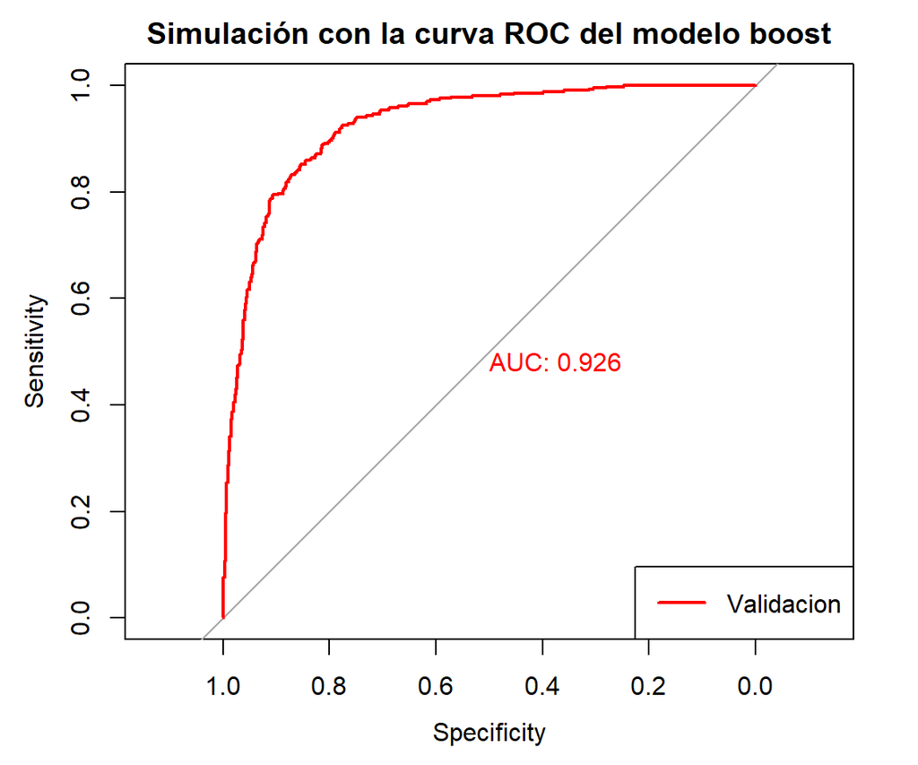

```
## Cross-Validated (5 fold, repeated 3 times) Confusion Matrix
##
## (entries are percentual average cell counts across resamples)
##
##           Reference
## Prediction    n    y
##          n 51.2  6.9
##          y  7.3 34.6
##
##  Accuracy (average) : 0.8585
##
##
##
##    Cell Contents
## |-------------------------|
## |                       N |
## | Chi-square contribution |
## |           N / Row Total |
## |           N / Col Total |
## |         N / Table Total |
## |-------------------------|
##
##
## Total Observations in Table:  974
##
##
##              | validacion$Revenue
##       pred_Y |         n |         y | Row Total |
## -------------|-----------|-----------|-----------|
##            n |       512 |        83 |       595 |
##              |    77.051 |   108.710 |           |
##              |     0.861 |     0.139 |     0.611 |
##              |     0.898 |     0.205 |           |
##              |     0.526 |     0.085 |           |
## -------------|-----------|-----------|-----------|
##            y |        58 |       321 |       379 |
##              |   120.964 |   170.667 |           |
##              |     0.153 |     0.847 |     0.389 |
##              |     0.102 |     0.795 |           |
##              |     0.060 |     0.330 |           |
```

[output cut: 14 more lines]

```
## x           n         y
##   n 0.8605042 0.1394958
##   y 0.1530343 0.8469657
##
## $prop.col
##    y
## x           n         y
##   n 0.8982456 0.2054455
##   y 0.1017544 0.7945545
##
## $prop.tbl
##    y
## x            n          y
##   n 0.52566735 0.08521561
##   y 0.05954825 0.32956879
```

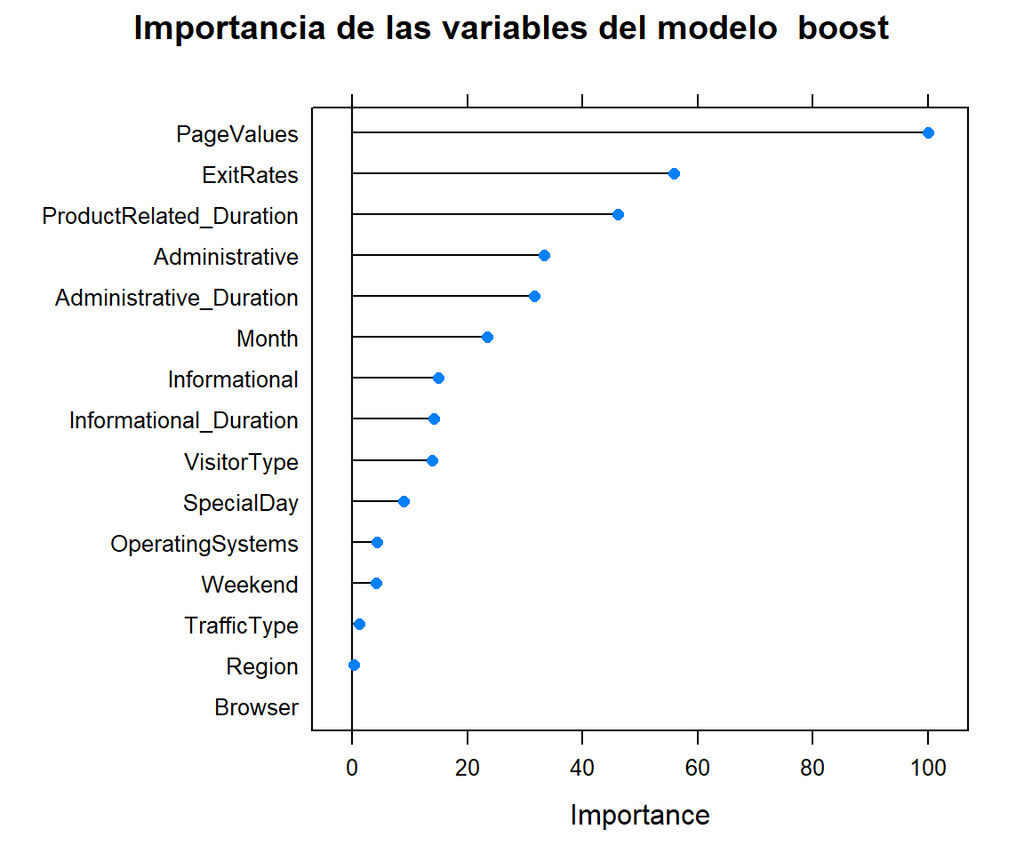

```r
#Random forest
roc_rf<-Resul_Modelo(rf)
```

```
## [1] "Mejor modelo:"
##    mtry
## 10   19
## [1] "ROC del modelo con el fichero de validación: 0.932412714955706"
```

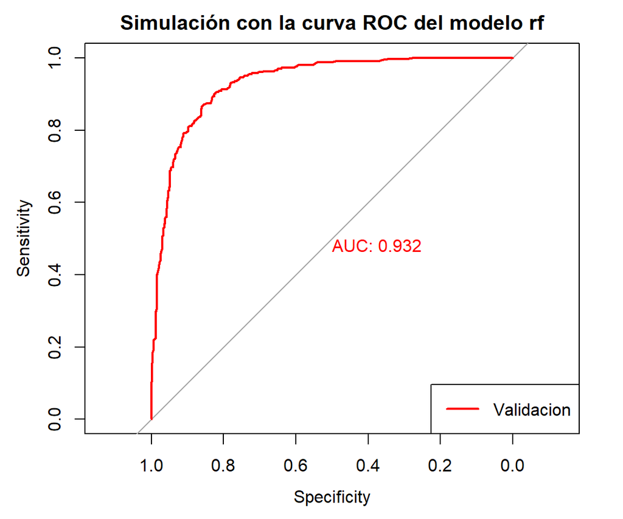

```
## Cross-Validated (5 fold, repeated 3 times) Confusion Matrix
##
## (entries are percentual average cell counts across resamples)
##
##           Reference
## Prediction    n    y
##          n 52.0  6.9
##          y  6.5 34.6
##
##  Accuracy (average) : 0.8662
##
##
##
##    Cell Contents
## |-------------------------|
## |                       N |
## | Chi-square contribution |
## |           N / Row Total |
## |           N / Col Total |
## |         N / Table Total |
## |-------------------------|
##
##
## Total Observations in Table:  974
##
##
##              | validacion$Revenue
##       pred_Y |         n |         y | Row Total |
## -------------|-----------|-----------|-----------|
##            n |       512 |        78 |       590 |
##              |    80.505 |   113.584 |           |
##              |     0.868 |     0.132 |     0.606 |
##              |     0.898 |     0.193 |           |
##              |     0.526 |     0.080 |           |
## -------------|-----------|-----------|-----------|
##            y |        58 |       326 |       384 |
##              |   123.692 |   174.516 |           |
##              |     0.151 |     0.849 |     0.394 |
##              |     0.102 |     0.807 |           |
##              |     0.060 |     0.335 |           |
```

[output cut: 14 more lines]

```
## x           n         y
##   n 0.8677966 0.1322034
##   y 0.1510417 0.8489583
##
## $prop.col
##    y
## x           n         y
##   n 0.8982456 0.1930693
##   y 0.1017544 0.8069307
##
## $prop.tbl
##    y
## x            n          y
##   n 0.52566735 0.08008214
##   y 0.05954825 0.33470226
```

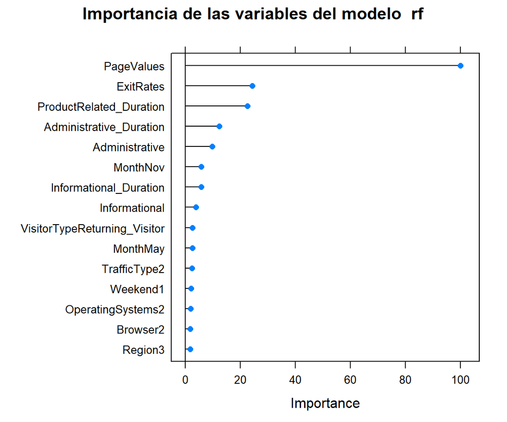

### Tabla comparativa de modelos

```r
set.seed(7)
confusion_mlp <- confusionMatrix(data = prediccion_mlp, reference = validacion$Revenue)
confusion_svm <- confusionMatrix(data = prediccion_svm, reference = validacion$Revenue)
confusion_knn <- confusionMatrix(data = prediccion_knn, reference = validacion$Revenue)
confusion_boost <- confusionMatrix(data = prediccion_boost, reference = validacion$Revenue)
confusion_rf <- confusionMatrix(data = prediccion_rf, reference = validacion$Revenue)
resultados <- data.frame(
  modelo=c(mlp$modelInfo$label,
           svm$modelInfo$label,
           knn$modelInfo$label,
           boost$modelInfo$label,
           rf$modelInfo$label),

  AUC=round(c(auc(roc_mlp),
               auc(roc_svm),
               auc(roc_knn),
               auc(roc_boost),
               auc(roc_rf)),digits=3),


  Accuracy=round(c(confusion_mlp[["overall"]][["Accuracy"]],
                    confusion_svm[["overall"]][["Accuracy"]],
                    confusion_knn[["overall"]][["Accuracy"]],
                    confusion_boost[["overall"]][["Accuracy"]],
                    confusion_rf[["overall"]][["Accuracy"]]),digits=3),


  AciertosClaseSI=round(c(confusion_mlp[["byClass"]][["Pos Pred Value"]],
                          confusion_svm[["byClass"]][["Pos Pred Value"]],
                          confusion_knn[["byClass"]][["Pos Pred Value"]],
                          confusion_boost[["byClass"]][["Pos Pred Value"]],
                          confusion_rf[["byClass"]][["Pos Pred Value"]]),digits=3),

  AciertosClaseNO=round(c(confusion_mlp[["byClass"]][["Neg Pred Value"]],
                          confusion_svm[["byClass"]][["Neg Pred Value"]],
                          confusion_knn[["byClass"]][["Neg Pred Value"]],
                          confusion_boost[["byClass"]][["Neg Pred Value"]],
                          confusion_rf[["byClass"]][["Neg Pred Value"]]),digits=3))




resultados %>%
  mutate(
    modelo = modelo,
    AUC = color_tile("white", "orange")(AUC),
    Accuracy = color_tile("white", "lightblue")(Accuracy),
    AciertosClaseSI = color_tile("white", "hotpink")(AciertosClaseSI),
    AciertosClaseNO = color_tile("white", "hotpink")(AciertosClaseNO)
  ) %>%
  select(modelo, everything()) %>%
  kable(escape = F) %>%
  kable_styling("hover", full_width = F) %>%
  add_header_above(c(" ", "Test" = 4))
```

| modelo | Test AUC | Test Accuracy | Test AciertosClaseSI | Test AciertosClaseNO |
| --- | --- | --- | --- | --- |
| Multi-Layer Perceptron | 0.909 | 0.835 | 0.862 | 0.797 |
| Support Vector Machines with Radial Basis Function Kernel | 0.906 | 0.818 | 0.801 | 0.854 |
| k-Nearest Neighbors | 0.853 | 0.779 | 0.775 | 0.787 |
| AdaBoost Classification Trees | 0.926 | 0.855 | 0.861 | 0.847 |
| Random Forest | 0.932 | 0.860 | 0.868 | 0.849 |

```r
modelos<- list(GLM=glm, MLP=mlp, SVM=svm, KNN=knn, ADABOOST=boost, RF=rf)
Comparativa <- as.data.frame(Result (modelos))
Comparativa %>%
  mutate(
    ROC = color_tile("white", "orange")(ROC),
    `ROC Validación` = color_tile("white", "orange")(`ROC Validación`),
    Sens = color_tile("white", "lightblue")(Sens),
    Spec= color_tile("white", "lightblue")(Spec),
    Accuracy = color_tile("white", "hotpink")(Accuracy),
    Kappa = color_tile("white", "hotpink")(Kappa)
  ) %>%
  select(everything()) %>%
  kable(escape = F) %>%
  kable_styling("hover", full_width = F)
```

| Modelo | ROC | Sens | Spec | Accuracy | Kappa | ROC Validación |
| --- | --- | --- | --- | --- | --- | --- |
| glm | 0.896 | 0.905 | 0.696 | 0.818 | 0.616 | 0.891 |
| mlp | 0.916 | 0.865 | 0.839 | 0.854 | 0.701 | 0.909 |
| svmRadial | 0.912 | 0.92 | 0.698 | 0.828 | 0.635 | 0.906 |
| knn | 0.87 | 0.892 | 0.629 | 0.782 | 0.537 | 0.855 |
| adaboost | 0.928 | 0.876 | 0.834 | 0.858 | 0.709 | 0.926 |
| rf | 0.938 | 0.889 | 0.834 | 0.866 | 0.724 | 0.932 |

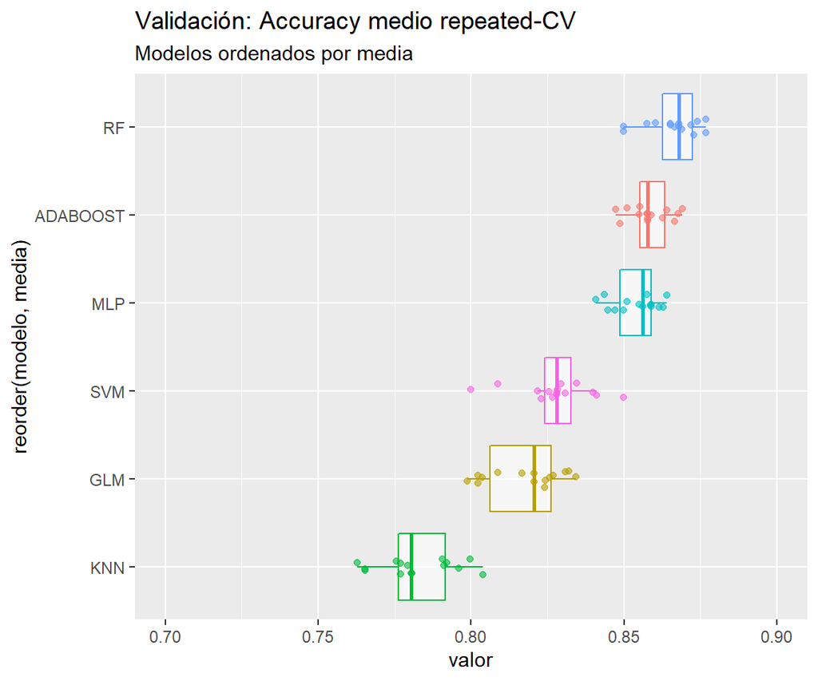

```r
#Resultados por modelo
resultados <- resamples(modelos)
metricas_resamples <- resultados$values %>%
                         gather(key = "modelo", value = "valor", -Resample) %>%
                         separate(col = "modelo", into = c("modelo", "metrica"),
                                  sep = "~", remove = TRUE)

metricas_resamples %>% filter(metrica == "Accuracy") %>%
  group_by(modelo) %>%
  mutate(media = mean(valor)) %>%
  ungroup() %>%
  ggplot(aes(x = reorder(modelo, media), y = valor, color = modelo)) +
    geom_boxplot(alpha = 0.6, outlier.shape = NA) +
    geom_jitter(width = 0.1, alpha = 0.6) +
    scale_y_continuous(limits = c(0.7, 0.9)) +
    labs(title = "Validación: Accuracy medio repeated-CV",
         subtitle = "Modelos ordenados por media") +
    coord_flip() +
    theme(legend.position = "none")
```

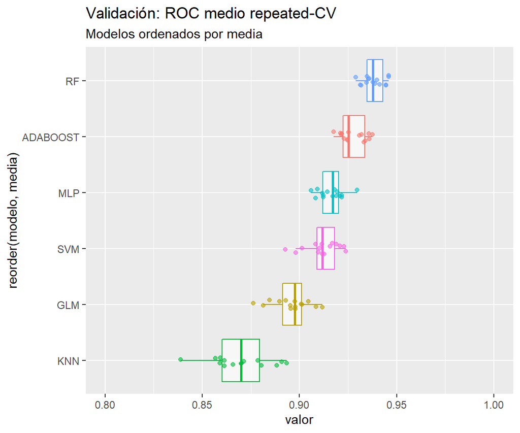

```r
metricas_resamples %>% filter(metrica == "ROC") %>%
  group_by(modelo) %>%
  mutate(media = mean(valor)) %>%
  ungroup() %>%
  ggplot(aes(x = reorder(modelo, media), y = valor, color = modelo)) +
    geom_boxplot(alpha = 0.6, outlier.shape = NA) +
    geom_jitter(width = 0.1, alpha = 0.6) +
    scale_y_continuous(limits = c(0.8, 1)) +
    labs(title = "Validación: ROC medio repeated-CV",
         subtitle = "Modelos ordenados por media") +
    coord_flip() +
    theme(legend.position = "none")
```

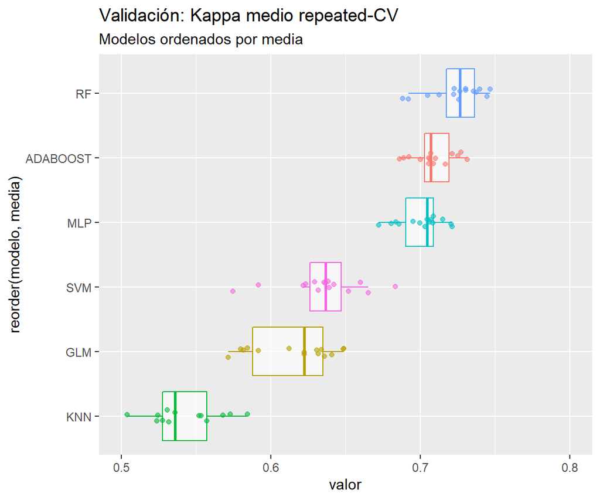

```r
metricas_resamples %>% filter(metrica == "Kappa") %>%
  group_by(modelo) %>%
  mutate(media = mean(valor)) %>%
  ungroup() %>%
  ggplot(aes(x = reorder(modelo, media), y = valor, color = modelo)) +
    geom_boxplot(alpha = 0.6, outlier.shape = NA) +
    geom_jitter(width = 0.1, alpha = 0.6) +
    scale_y_continuous(limits = c(0.5, 0.8)) +
    labs(title = "Validación: Kappa medio repeated-CV",
         subtitle = "Modelos ordenados por media") +
    coord_flip() +
    theme(legend.position = "none")
```

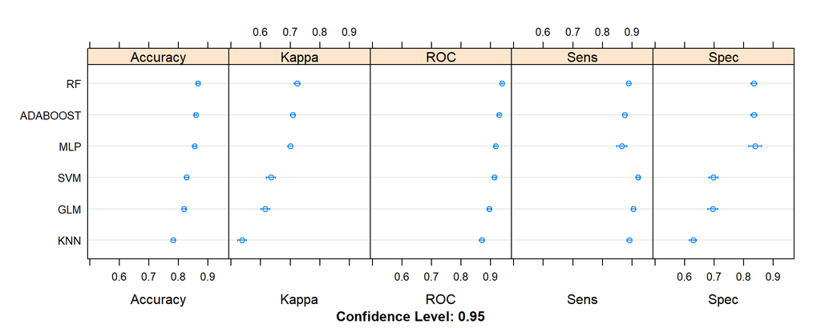

```r
#para verlos en las mismas escalas
dotplot(resultados,layout = c(5, 1))
```

Se puede observar como el modelo GLM proporciona mejor rendimiento en general que KNN. SVM, GLM y KNN tienen una mayor sensibilidad que RF, ADABOOST o MLP pero en el resto de medidas están bastante por debajo. No solo nos interesa clasificar bien a los positivos, sino a los negativos. Aunque en este caso particular lo más interesante sea clasificar bien a los positivos ya que son los que van a comprar, para poder aplicar las medidas necesarias para incentivar este caso.

Se muestran más métricas para los resultados, se observa que para la mayoría (excepto knn que es el peor método) el índice Kappa está por encima de 0.6 lo que indica concordancia elevada, este estadístico determina la precision del modelo a la hora de predecir la clase verdadera.

#### Diferencias entre modelos

```r
#Diferencias entre modelos
diferencias <- diff(resultados)
summary(diferencias)
```

```
##
## Call:
## summary.diff.resamples(object = diferencias)
##
## p-value adjustment: bonferroni
## Upper diagonal: estimates of the difference
## Lower diagonal: p-value for H0: difference = 0
##
## Accuracy
##          GLM       MLP       SVM       KNN       ADABOOST  RF
## GLM                -0.036003 -0.009578  0.035653 -0.040366 -0.048061
## MLP      2.213e-08            0.026425  0.071656 -0.004363 -0.012058
## SVM      0.03899   1.059e-06            0.045231 -0.030788 -0.038483
## KNN      4.451e-05 4.024e-10 6.636e-07           -0.076019 -0.083714
## ADABOOST 3.776e-07 0.70902   1.001e-05 4.857e-10           -0.007695
## RF       1.423e-09 4.596e-05 5.062e-08 4.901e-11 0.02847
##
## Kappa
##          GLM       MLP       SVM       KNN       ADABOOST  RF
## GLM                -0.085022 -0.019216  0.078503 -0.093079 -0.108186
## MLP      1.073e-08            0.065806  0.163525 -0.008057 -0.023164
## SVM      0.05565   2.160e-07            0.097719 -0.073863 -0.088970
## KNN      5.613e-05 1.542e-10 1.037e-06           -0.171582 -0.186689
## ADABOOST 1.509e-07 0.94402   2.457e-06 2.153e-10           -0.015107
## RF       7.163e-10 5.252e-05 1.562e-08 3.269e-11 0.03892
##
## ROC
##          GLM       MLP       SVM       KNN       ADABOOST  RF
## GLM                -0.020411 -0.015997  0.025966 -0.032220 -0.042429
## MLP      1.281e-06            0.004414  0.046377 -0.011809 -0.022018
## SVM      6.608e-06 1.0000000            0.041963 -0.016223 -0.026432
## KNN      0.0002089 8.544e-09 1.862e-07           -0.058186 -0.068394
## ADABOOST 1.275e-07 0.0035300 2.567e-05 1.327e-08           -0.010208
## RF       7.601e-10 4.040e-07 1.150e-08 4.432e-10 4.849e-07
##
## Sens
##          GLM       MLP       SVM       KNN       ADABOOST  RF
## GLM                 0.040058 -0.014912  0.013450  0.028947  0.015936
## MLP      0.0048702           -0.054971 -0.026608 -0.011111 -0.024123
## SVM      0.0085342 0.0001684            0.028363  0.043860  0.030848
## KNN      0.0769199 0.1122281 9.522e-05            0.015497  0.002485
## ADABOOST 6.248e-05 1.0000000 4.016e-07 0.1187092           -0.013012
## RF       0.0213297 0.1362176 3.640e-05 1.0000000 0.0100154
##
## Spec
##          GLM       MLP       SVM       KNN       ADABOOST  RF
## GLM                -0.143204 -0.002061  0.066935 -0.138047 -0.138254
## MLP      3.465e-07            0.141143  0.210139  0.005157  0.004950
## SVM      1.0000000 1.626e-07            0.068996 -0.135986 -0.136193
## KNN      0.0008359 5.606e-10 0.0001897           -0.204982 -0.205189
## ADABOOST 1.363e-10 1.0000000 4.880e-11 4.682e-12           -0.000207
## RF       1.274e-11 1.0000000 1.993e-12 6.432e-12 1.0000000
```

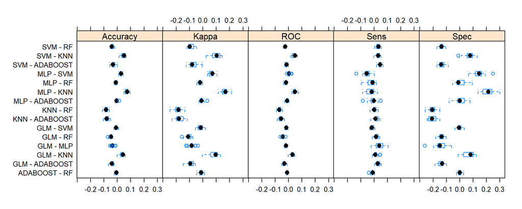

```r
bwplot(diferencias,layout = c(5, 1))
```

## Resultados Random Forest

```r
print(rf$finalModel)
```

```
##
## Call:
##  randomForest(x = x, y = y, mtry = param$mtry)
##                Type of random forest: classification
##                      Number of trees: 500
## No. of variables tried at each split: 19
##
##         OOB estimate of  error rate: 12.9%
## Confusion matrix:
##      n    y class.error
## n 2040  240   0.1052632
## y  263 1355   0.1625464
```

```r
table(prediccion_rf,validacion$Revenue)
```

```
##
## prediccion_rf   n   y
##             n 512  78
##             y  58 326
```

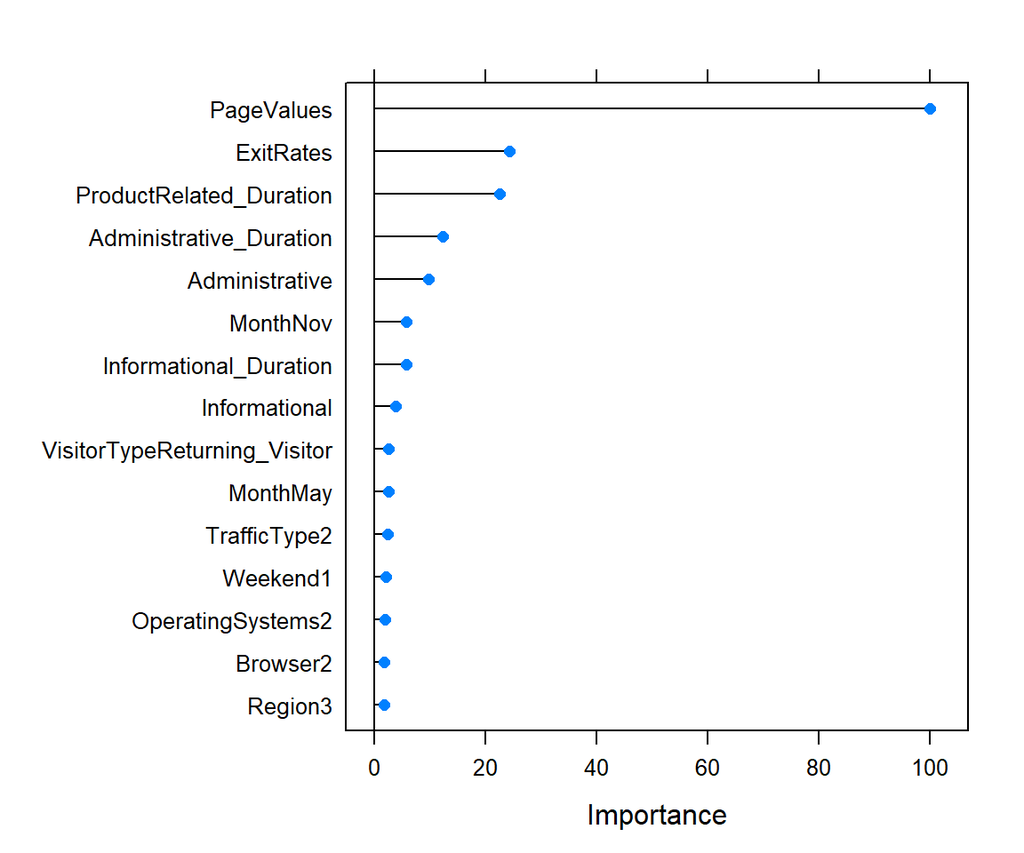

```r
plot(varImp(rf),top=15)
```

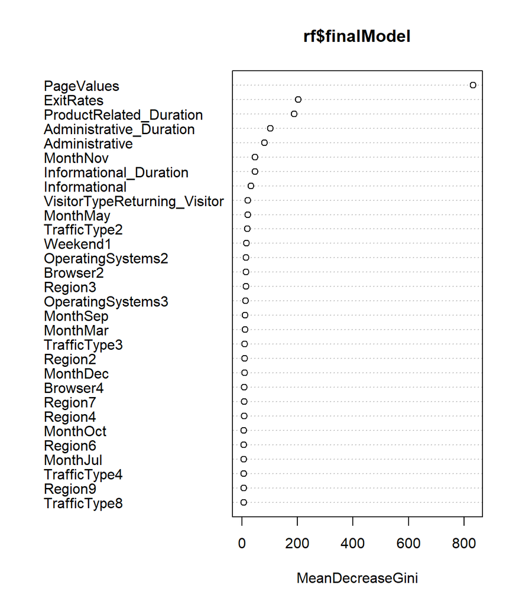

```r
varImpPlot(rf$finalModel)
```

Si vemos la importancia medida en valores del indice de Gini, el cual nos indica la importancia de la variable a la hora de separar los nodos, como ve observa ni las regiones, ni el tipo de trafico, sistemas operativos o navegadores tienen casi importancia a la hora de separar los nodos.